# Unit Project 03

2026-02-06

Below is a template to get you started on the Unit 3 Project. Make sure you edit the metadata above to include your name. For questions that include code, the template to produce `R` chunks is below. **Any code you write that produces an output must be fully visible in the HTML document you hand in!**

```r
library(tidyverse)
library(ggplot2)
library(GGally)
library(MASS)
library(klaR)
library(maps)
library(dismo)
```

# Part I: Morphological Data

## Question 1

```r
iris %>% group_by(Species) %>% summarize(across(where(is.numeric), mean))
```

```
## # A tibble: 3 × 5
##   Species    Sepal.Length Sepal.Width Petal.Length Petal.Width
##   <fct>             <dbl>       <dbl>        <dbl>       <dbl>
## 1 setosa             5.01        3.43         1.46       0.246
## 2 versicolor         5.94        2.77         4.26       1.33
## 3 virginica          6.59        2.97         5.55       2.03
```

## Question 2

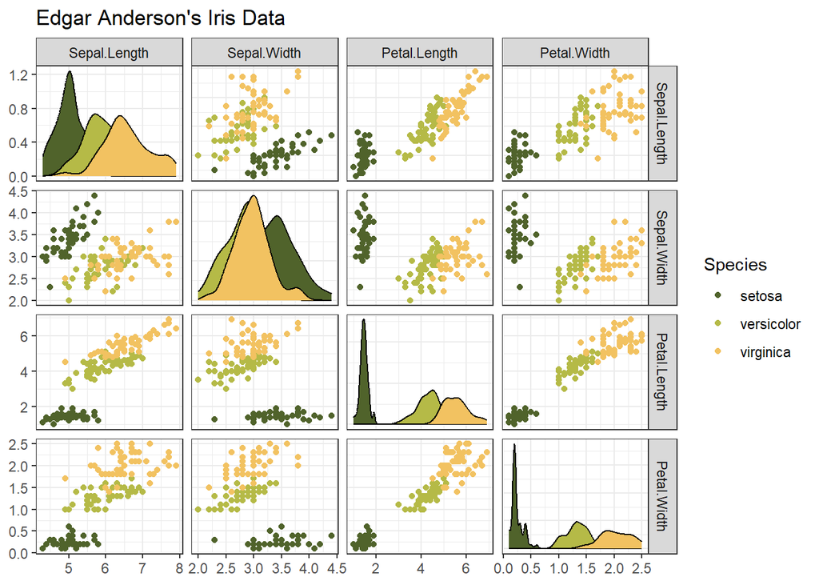

```r
ggpairs(iris, columns=1:4, aes(color=Species), title="Edgar Anderson's Iris Data",
        upper=list(continuous="points"), axisLabels="show", legend = 10,
        columnlabels=colnames(data[columns])) +
  scale_color_manual(values=c("#50632B", "#B5BA47", "#F2C261")) +
  scale_fill_manual(values=c("#50632B", "#B5BA47", "#F2C261")) +
  theme_bw()
```

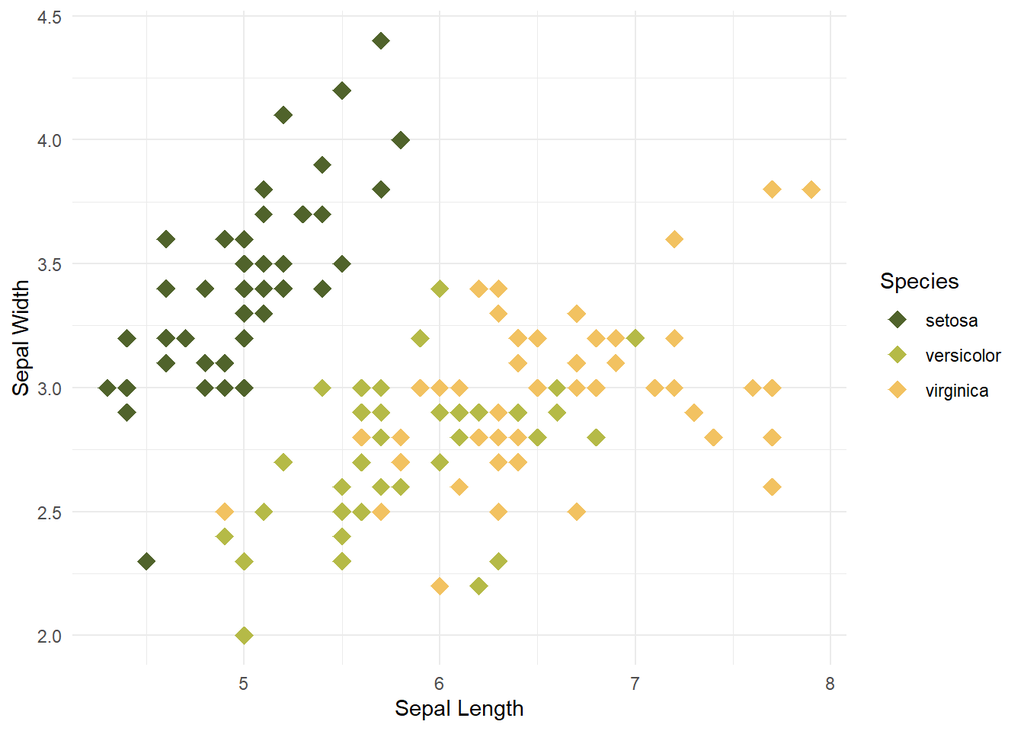

```r
# will also make individual graphs!

#Sepal Length vs Sepal Width and vice versa
ggplot(iris, aes(x = Sepal.Length, y = Sepal.Width, color = Species, group = Species)) +
  geom_point(size = 4, pch = 18) +
  labs(x = "Sepal Length", y = "Sepal Width") +
  theme_minimal() +
  scale_color_manual(values=c("#50632B", "#B5BA47", "#F2C261"))
```

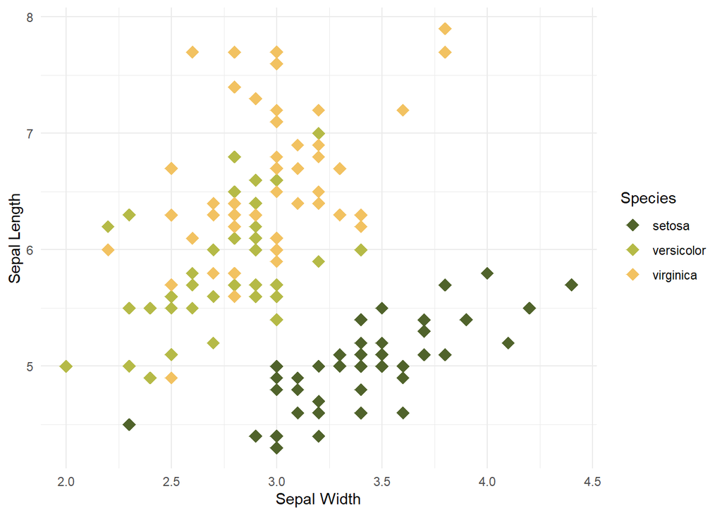

```r
ggplot(iris, aes(x = Sepal.Width, y = Sepal.Length, color = Species, group = Species)) +
  geom_point(size = 4, pch = 18) +
  labs(x = "Sepal Width", y = "Sepal Length") +
  theme_minimal() +
  scale_color_manual(values=c("#50632B", "#B5BA47", "#F2C261"))
```

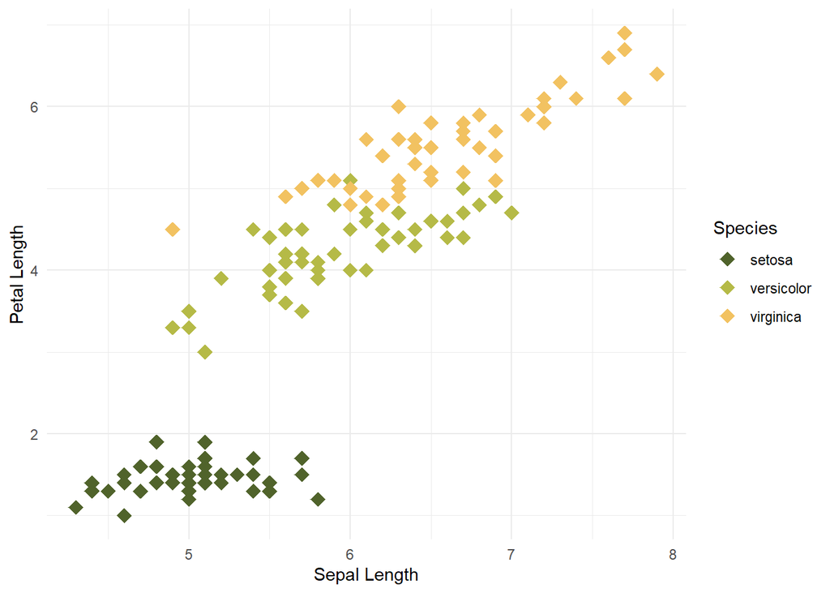

```r
# Sepal Length vs Petal Length and vice versa
ggplot(iris, aes(x = Sepal.Length, y = Petal.Length, color = Species, group = Species)) +
  geom_point(size = 4, pch = 18) +
  labs(x = "Sepal Length", y = "Petal Length") +
  theme_minimal() +
  scale_color_manual(values=c("#50632B", "#B5BA47", "#F2C261"))
```

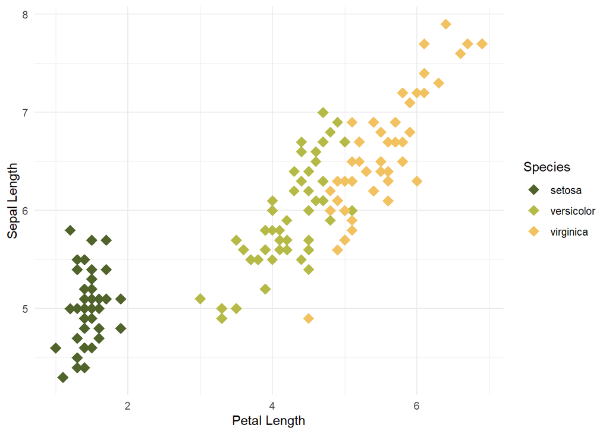

```r
ggplot(iris, aes(x = Petal.Length, y = Sepal.Length, color = Species, group = Species)) +
  geom_point(size = 4, pch = 18) +
  labs(x = "Petal Length", y = "Sepal Length") +
  theme_minimal() +
  scale_color_manual(values=c("#50632B", "#B5BA47", "#F2C261"))
```

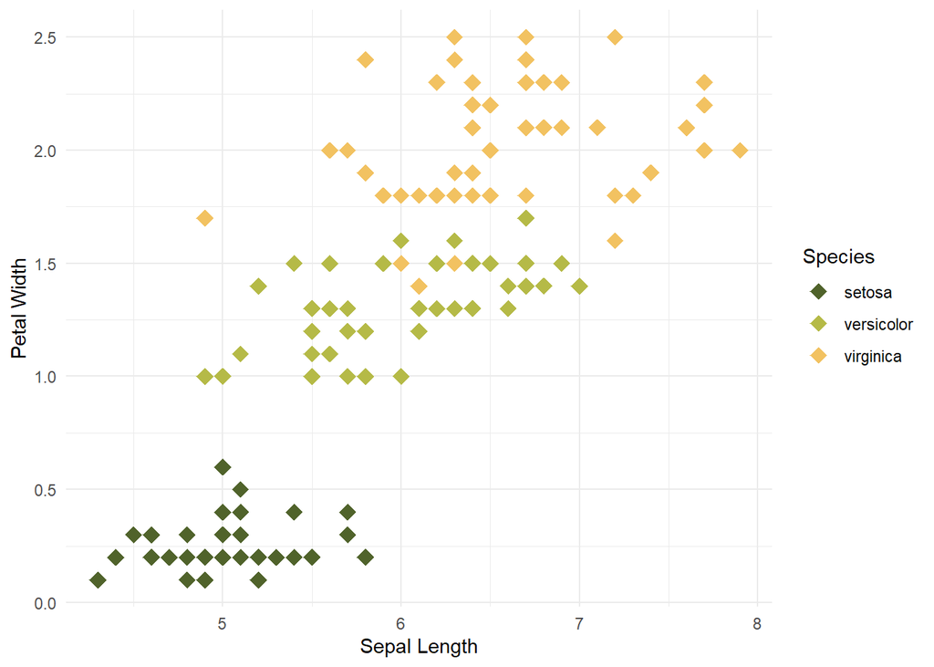

```r
# Sepal Length vs Petal Width and vice versa
ggplot(iris, aes(x = Sepal.Length, y = Petal.Width, color = Species, group = Species)) +
  geom_point(size = 4, pch = 18) +
  labs(x = "Sepal Length", y = "Petal Width") +
  theme_minimal() +
  scale_color_manual(values=c("#50632B", "#B5BA47", "#F2C261"))
```

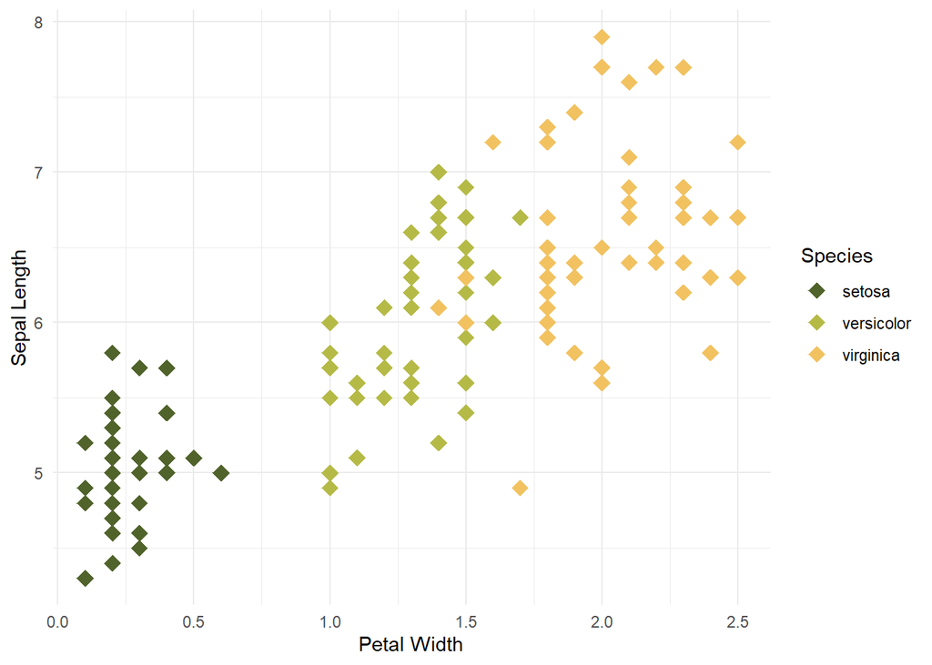

```r
ggplot(iris, aes(x = Petal.Width, y = Sepal.Length, color = Species, group = Species)) +
  geom_point(size = 4, pch = 18) +
  labs(x = "Petal Width", y = "Sepal Length") +
  theme_minimal() +
  scale_color_manual(values=c("#50632B", "#B5BA47", "#F2C261"))
```

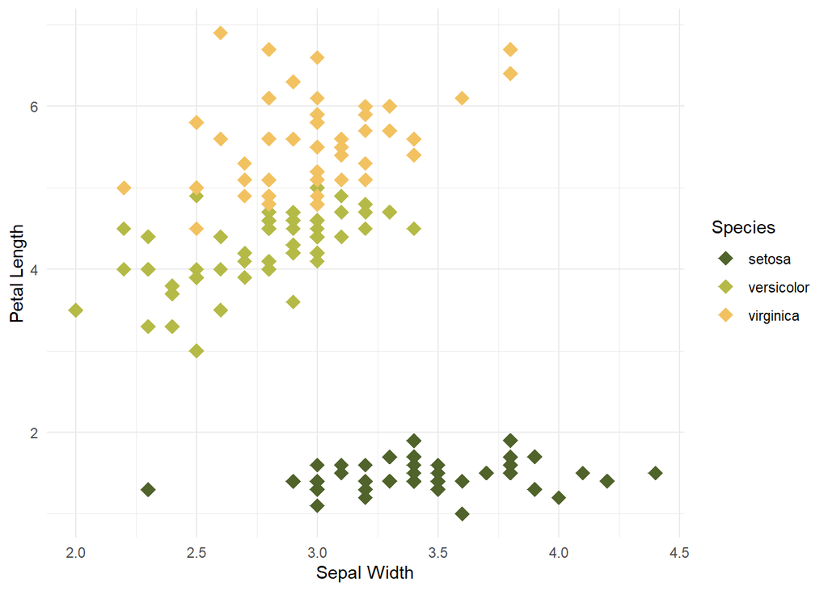

```r
# Sepal Width vs Petal Length and vice versa
ggplot(iris, aes(x = Sepal.Width, y = Petal.Length, color = Species, group = Species)) +
  geom_point(size = 4, pch = 18) +
  labs(x = "Sepal Width", y = "Petal Length") +
  theme_minimal() +
  scale_color_manual(values=c("#50632B", "#B5BA47", "#F2C261"))
```

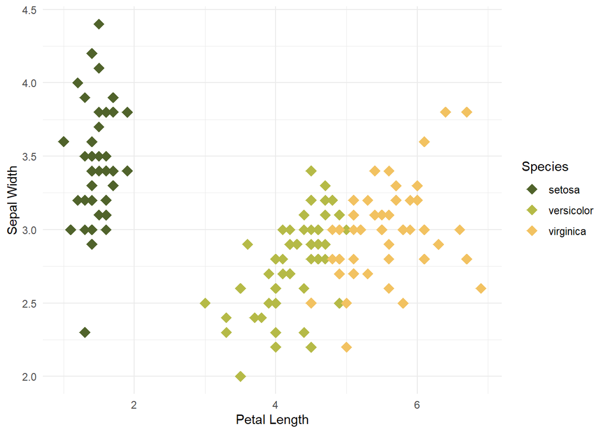

```r
ggplot(iris, aes(x = Petal.Length, y = Sepal.Width, color = Species, group = Species)) +
  geom_point(size = 4, pch = 18) +
  labs(x = "Petal Length", y = "Sepal Width") +
  theme_minimal() +
  scale_color_manual(values=c("#50632B", "#B5BA47", "#F2C261"))
```

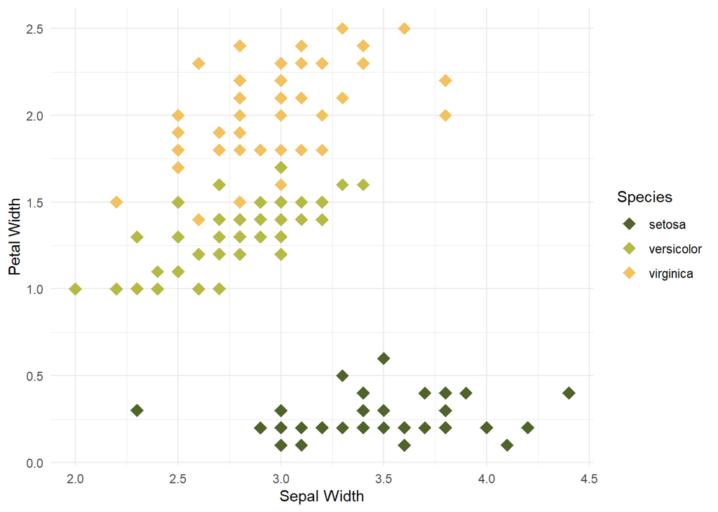

```r
# Sepal Width vs Petal Width and vice versa
ggplot(iris, aes(x = Sepal.Width, y = Petal.Width, color = Species, group = Species)) +
  geom_point(size = 4, pch = 18) +
  labs(x = "Sepal Width", y = "Petal Width") +
  theme_minimal() +
  scale_color_manual(values=c("#50632B", "#B5BA47", "#F2C261"))
```

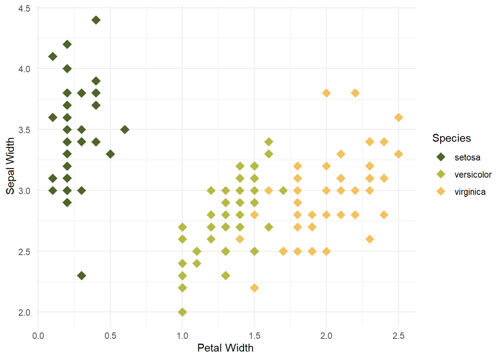

```r
ggplot(iris, aes(x = Petal.Width, y = Sepal.Width, color = Species, group = Species)) +
  geom_point(size = 4, pch = 18) +
  labs(x = "Petal Width", y = "Sepal Width") +
  theme_minimal() +
  scale_color_manual(values=c("#50632B", "#B5BA47", "#F2C261"))
```

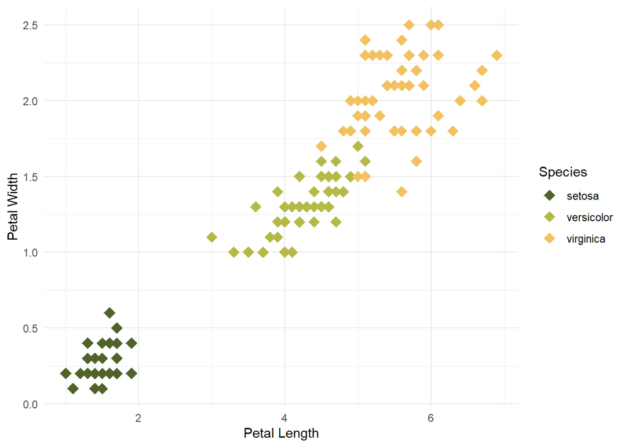

```r
# Petal Length vs Petal Width and vice versa
ggplot(iris, aes(x = Petal.Length, y = Petal.Width, color = Species, group = Species)) +
  geom_point(size = 4, pch = 18) +
  labs(x = "Petal Length", y = "Petal Width") +
  theme_minimal() +
  scale_color_manual(values=c("#50632B", "#B5BA47", "#F2C261"))
```

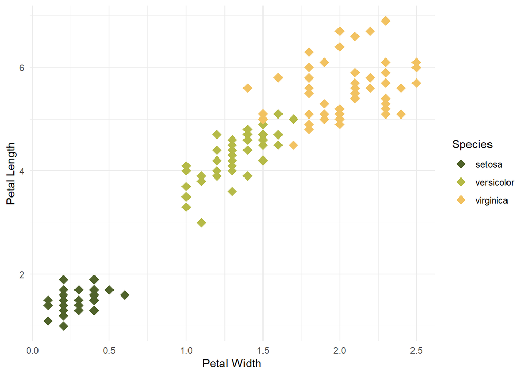

```r
ggplot(iris, aes(x = Petal.Width, y = Petal.Length, color = Species, group = Species)) +
  geom_point(size = 4, pch = 18) +
  labs(x = "Petal Width", y = "Petal Length") +
  theme_minimal() +
  scale_color_manual(values=c("#50632B", "#B5BA47", "#F2C261"))
```

## Question 3

#### Petal width vs. Sepal width

```r
# list of each row's species designation
group <- iris %>%
  pull(Species)

# data frame wigth only the two columns we want
Q3.widths <- iris %>%
  dplyr::select(Petal.Width, Sepal.Width)

# do the linear discriminant analysis
Q3.widths.lda <- lda(Q3.widths, group)

# make predictions of the species in the data you give it
widths <- stats::predict(Q3.widths.lda, Q3.widths)

# get just the predictions
widths.preds <- widths$class

# make a table comparing the actual designation and the predictions
widths.table <- table(iris$Species, widths$class)
widths.table
```

```
##
##              setosa versicolor virginica
##   setosa         50          0         0
##   versicolor      0         49         1
##   virginica       0          4        46
```

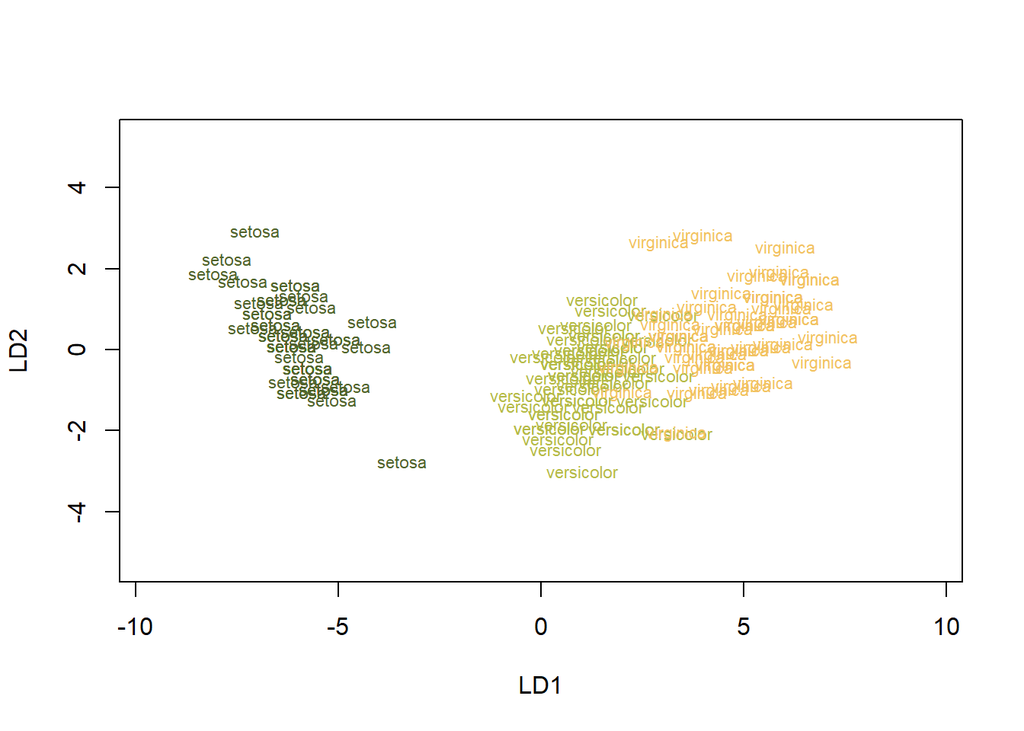

```r
# make a data frame comparing the actual designation for each individual
# and the predicted designation
iris.widths.predictions <- iris %>%
  dplyr::select(Species) %>%
  add_column(widths.preds)

# scatter plot using the 1st two discriminant dimensions
plot(Q3.widths.lda, col = c("#50632B", "#B5BA47", "#F2C261"
                            )[unclass(iris.widths.predictions$Species)], xlim = c(-10, 10))
```

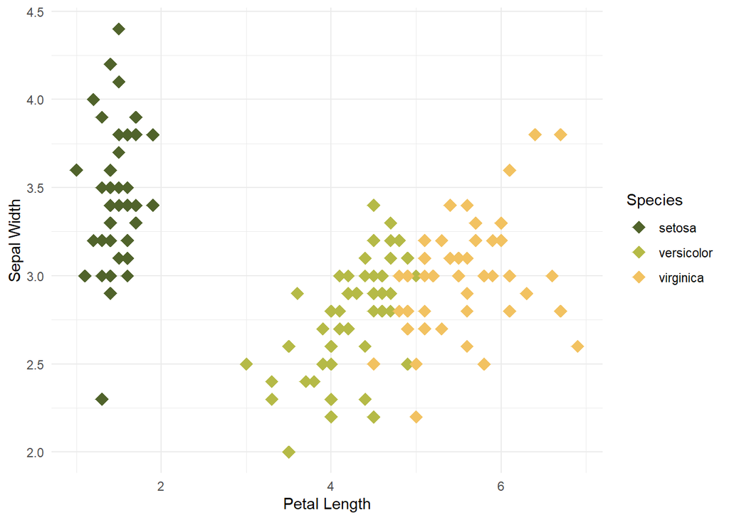

```r
# original scatterplot
ggplot(iris, aes(x = Petal.Length, y = Sepal.Width, color = Species, group = Species)) +
  geom_point(size = 4, pch = 18) +
  labs(x = "Petal Length", y = "Sepal Width") +
  theme_minimal() +
  scale_color_manual(values=c("#50632B", "#B5BA47", "#F2C261"))
```

#### Petal length vs. Sepal Length

```r
Q3.lengths <- iris %>%
  dplyr::select(Petal.Length, Sepal.Length)

Q3.lengths.lda <- lda(Q3.lengths, group)

lengths <- stats::predict(Q3.lengths.lda, Q3.lengths)

lengths.preds <- lengths$class

lengths.table <- table(iris$Species, lengths$class)
lengths.table
```

```
##
##              setosa versicolor virginica
##   setosa         50          0         0
##   versicolor      0         48         2
##   virginica       0          3        47
```

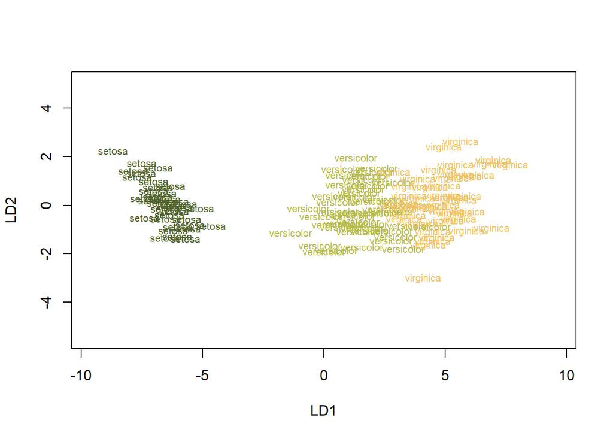

```r
iris.lengths.predictions <- iris %>%
  dplyr::select(Species) %>%
  add_column(lengths.preds)

plot(Q3.lengths.lda, col = c("#50632B", "#B5BA47", "#F2C261")[unclass(iris.lengths.predictions$Species)], xlim = c(-10, 10))
```

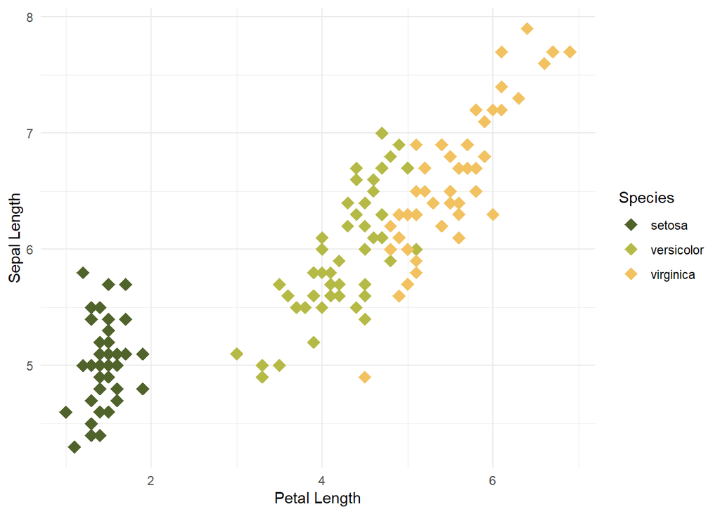

```r
ggplot(iris, aes(x = Petal.Length, y = Sepal.Length, color = Species, group = Species)) +
  geom_point(size = 4, pch = 18) +
  labs(x = "Petal Length", y = "Sepal Length") +
  theme_minimal() +
  scale_color_manual(values=c("#50632B", "#B5BA47", "#F2C261"))
```

## Question 4

# Part II: Geographical and Temporal Data

## Question 1

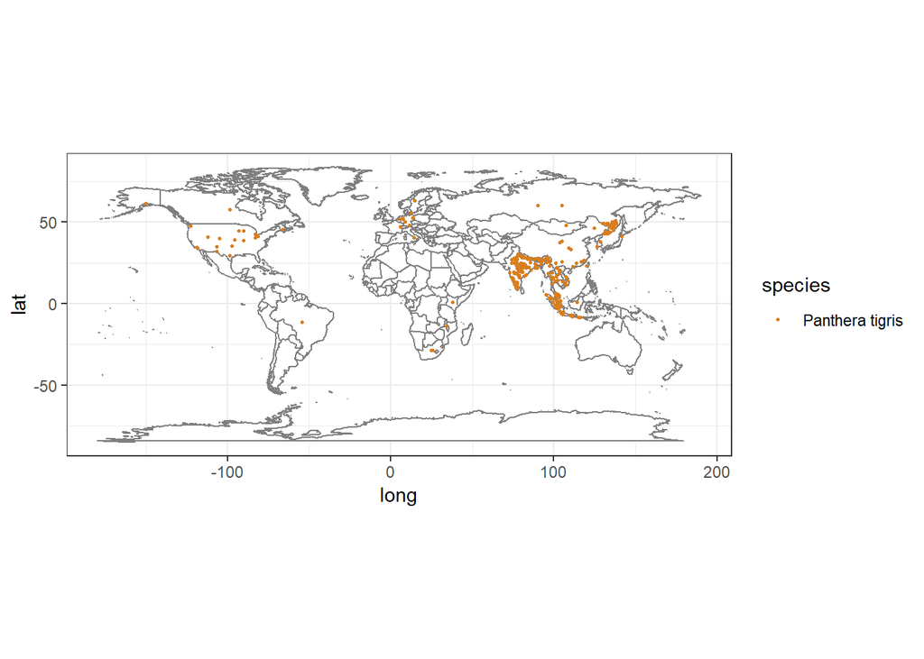

```r
#Dr. Delaney's code for get.gbif
# get.gbif <- function (genus, species, na.rm=TRUE, crop=TRUE)
# {
  #GBIF query
  # gps <- gbif(genus, species, geo=FALSE)
  #drop NA entries; note that this option is visited only with na.rm=TRUE
  # if(na.rm){gps <- subset(gps, !is.na(lon) & !is.na(lat))}
  # if(crop){
    # keep <- c(which(colnames(gps)=="species"),which(colnames(gps)=="lat"),which(colnames(gps)=="lon"),
              #which(colnames(gps)=="month"))
    # gps <- gps[keep]
  # }
  # return(gps)
# }

#using get.gbif to download tiger data
# tigers <- get.gbif("Panthera", "tigris")

#making tiger data into a file so i don't have to re-run get.gbif
# write_csv(tigers, file = "tigers.csv", col_names = TRUE)

tigersfromcsv <-read.csv("tigers.csv", header = T, sep = ",")

ggplot2::theme_set(theme_bw())

world.map <- map_data(map = "world")

ggplot(world.map, aes(long, lat, group = group)) +
  geom_polygon(fill = "white", colour = "grey50") +
  coord_quickmap() + geom_point(data = tigersfromcsv,
    mapping = aes(x = lon, y = lat, group = species, color = species), size = 0.5) +
  scale_color_manual(values=c("#D97E1E"))
```

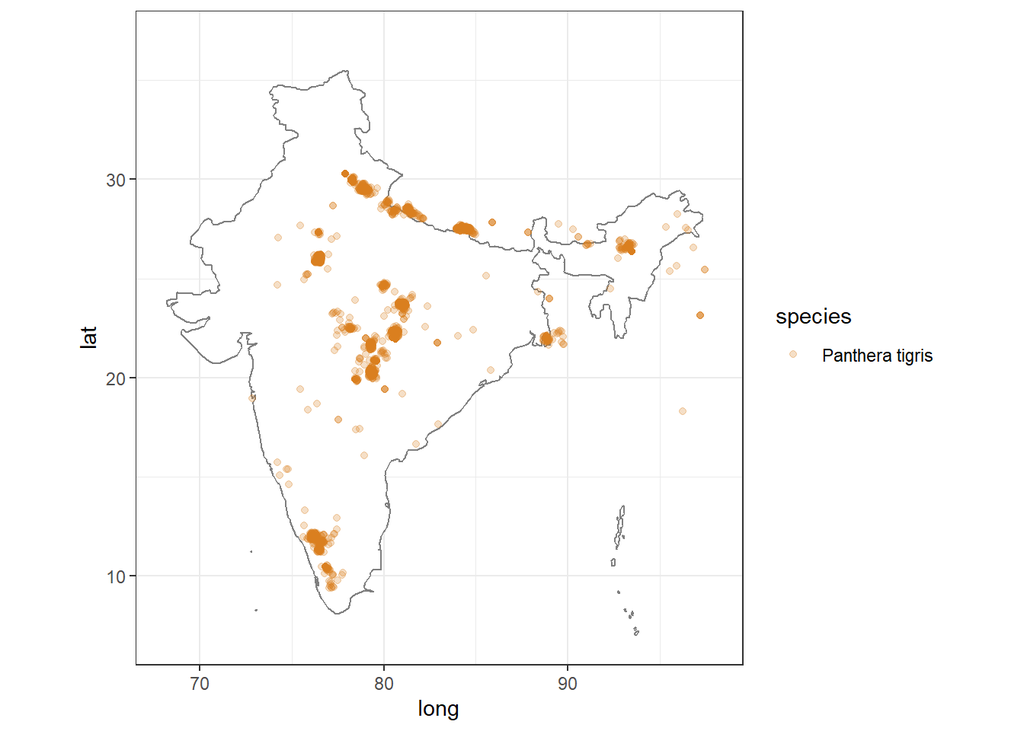

```r
india.map <- map_data(map="world", region="india")

ggplot(india.map, aes(long, lat, group = group)) +
  geom_polygon(fill = "white", colour = "grey50") +
  coord_quickmap() + geom_point(data = tigersfromcsv,
    mapping = aes(x = lon, y = lat, group = species, color = species), size = 1.5, alpha = 0.25) +
  xlim(68,98) +
  ylim(7,37) +
  scale_color_manual(values=c("#D97E1E"))
```

#### We can see that *Panthera tigris* is most commonly distributed in India according to GBIF data, and zooming into India, it seems like there are a few discrete populations (or perhaps urban/more densely populated areas, where more people will record observations) of tigers in India, with one central cluster that may overlap with a more northern cluster, and a third cluster near the southern tip (close to where my parents are from :3).

## Question 2

#### max long: -67.00742

#### min long: -124.6813

#### max lat: 49.38323

#### min lat: 25.12993

```r
iris_gps <-read.csv("iris_gps.csv", header = T, sep = ",")

us.map <- map_data(map = "usa")

us.map$long[which.max(us.map$long)]
```

```
## [1] -67.00742
```

```r
us.map$long[which.min(us.map$long)]
```

```
## [1] -124.6813
```

```r
us.map$lat[which.max(us.map$lat)]
```

```
## [1] 49.38323
```

```r
us.map$lat[which.min(us.map$lat)]
```

```
## [1] 25.12993
```

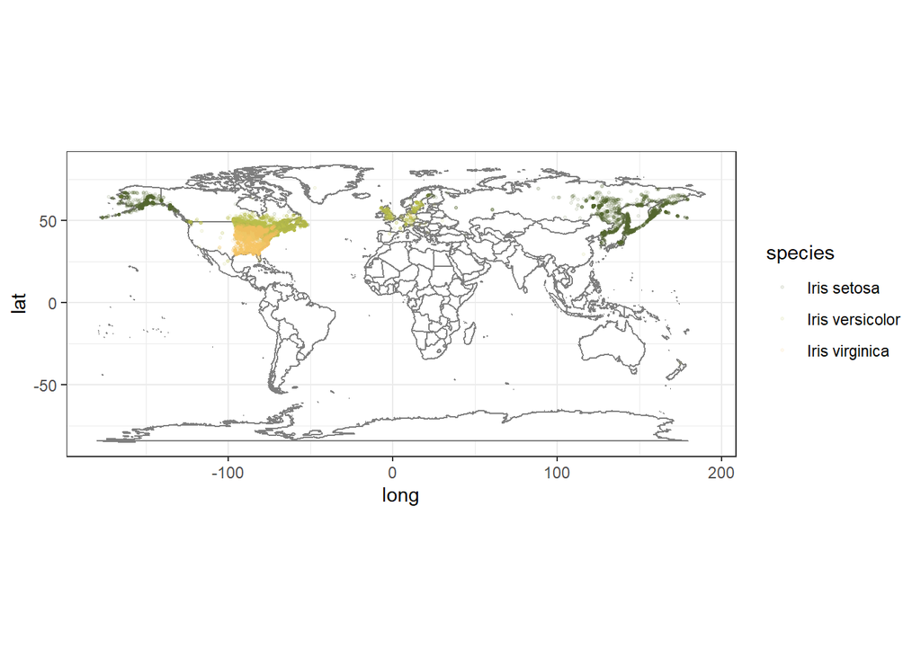

```r
iris_gps_usa <- iris_gps %>%
    dplyr::filter(lon >= -124.6813) %>%
    dplyr::filter(lon <= -67.00742) %>%
    dplyr::filter(lat >= 25.12993) %>%
    dplyr::filter(lat <= 49.38323)

ggplot(world.map, aes(long, lat, group = group)) +
  geom_polygon(fill = "white", colour = "grey50") +
  coord_quickmap() +
  geom_point(data = iris_gps,
    mapping = aes(x = lon, y = lat, group = species, color = species), size = 0.5, alpha=0.1) +
  scale_color_manual(values = c("#50632B", "#B5BA47", "#F2C261"))
```

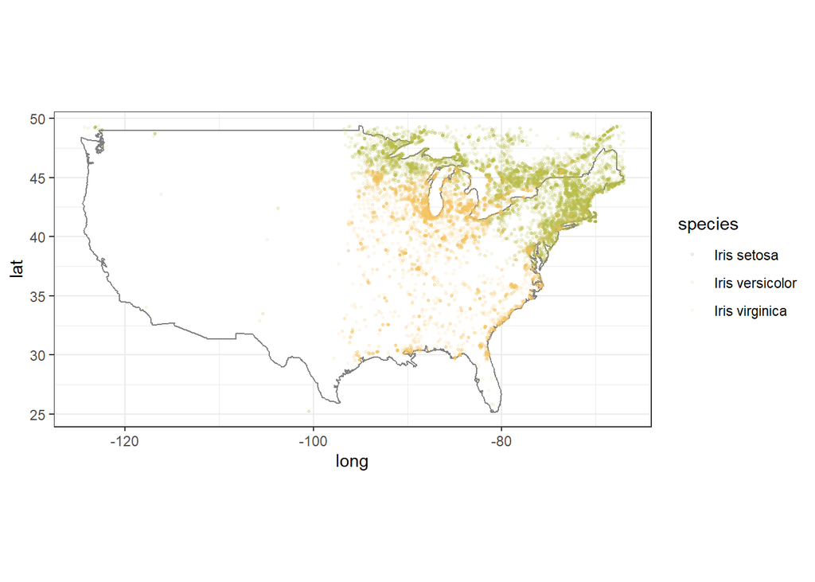

```r
ggplot(us.map, aes(long, lat, group = group)) +
  geom_polygon(fill = "white", colour = "grey50") +
  coord_quickmap() +
  geom_point(data = iris_gps_usa,
    mapping = aes(x = lon, y = lat, group = species, color = species), size = 0.5, alpha=0.1) +
  scale_color_manual(values = c("#50632B", "#B5BA47", "#F2C261"))
```

## Question 3

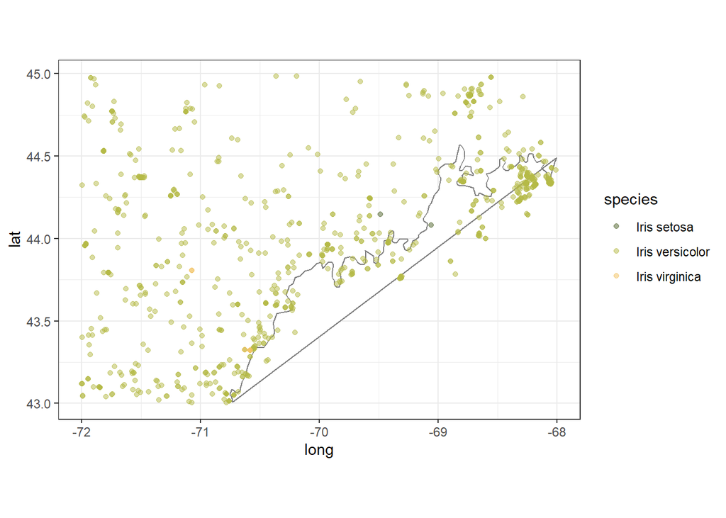

```r
# i narrowed down to these latitudes and longitudes by looking at the scale bars and adjusting them slightly each time successively. I found that if you don't also filter the map data, changing the x and y limits in the graph causes some really messed up lines to show up, and even on the following graph you can kind of see that being a problem (for some reason instead of making a normal border between water and land, there's a diagonal line and while I'm sure I could finagle it to make it look better, I'm not currently interested in making it look nicer.)
iris_gps_northeast <- iris_gps_usa %>%
    dplyr::filter(lon >= -72) %>%
    dplyr::filter(lon <= -68) %>%
    dplyr::filter(lat >= 43) %>%
    dplyr::filter(lat <= 45)

us.northeast <- us.map %>%
    dplyr::filter(long >= -72) %>%
    dplyr::filter(long <= -68) %>%
    dplyr::filter(lat >= 43) %>%
    dplyr::filter(lat <= 45)

ggplot(us.northeast, aes(long, lat, group = group)) +
  geom_polygon(fill = "white", colour = "grey50") +
  coord_quickmap() +
  geom_point(data = iris_gps_northeast,
    mapping = aes(x = lon, y = lat, group = species, color = species), size = 1.5, alpha = 0.5) +
  scale_color_manual(values = c("#50632B", "#B5BA47", "#F2C261"))
```

## Question 4

#### *Iris versicolor* is distributed primarily in the northern US, while *Iris virginica* is most common in central and southern US, with both species being more concentrated on the east half. *Iris setosa* is found rarely in the northern US, but only in the eastern and westernmost corners.

#### I think that the fact that *virginica* and *versicolor* co-occur but also have areas where they don’t overlap makes it likely that the two are different species. The fact that the two or three setosa occurrences occur in the middle of a lot of *versicolor* occurrences makes me think they may have been misidentified, even though the actual species is likely distinct based on its global distribution.

## Question 5

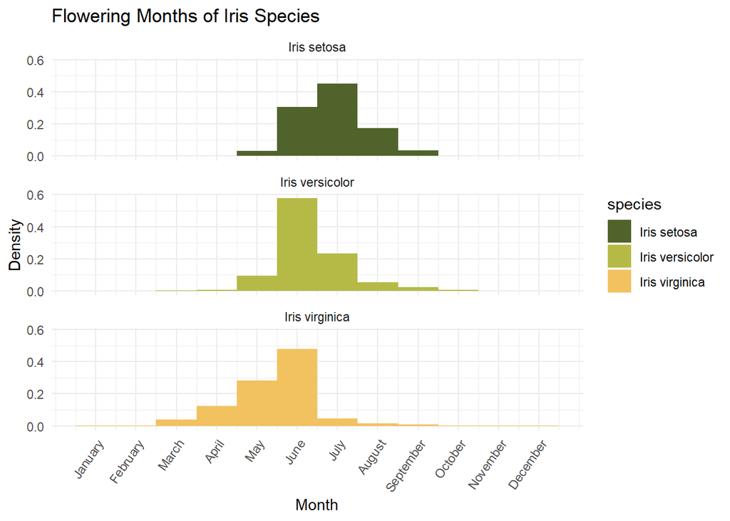

```r
ggplot(data = iris_gps, aes(x = month, y = after_stat(density),
  group = species, fill = species)) +
  geom_histogram(position = "dodge",
  binwidth = 1) +
  facet_wrap(~species, nrow = 3) +
  xlim(1, 12) + theme_minimal() +
  scale_x_continuous(breaks = seq_along(month.name),
    labels = month.name) +
  theme(axis.text.x = element_text(angle = 55, hjust = 1)) +
  labs(x = "Month", y = "Density", title = "Flowering Months of Iris Species") +
  scale_fill_manual(values = c("#50632B", "#B5BA47", "#F2C261"))
```

#### Evaluating reproductive isolation using flowering season is difficult because these plants all flower around the same season, and generally, plants do tend to flower when it is warm and the days are long (Spring and Summer). This graph kind of implies that the three species do flower at similar times, with all of them producing flowers during the month of June, which doesn’t really tell us anything about temporal isolation. Due to the nature of the data (being observations of flowers as a proxy for reproduction), we can’t know for sure whether or not the plants are actually producing pollen or being fertilized, and we can’t know if other factors like time of day or association with different pollinator species can reinforce reproductive isolation.

# Part III: Chromosomal data

## Question 1

```r
# make iris dataset into a table
iris_chrom_dataset <- read_csv("iris_chromosomes.csv", skip = 1, col_names = T,
                               trim_ws = T, skip_empty_rows = T)

# make new dataset w the scientific name, + only the columns we need
iris_chrom <- iris_chrom_dataset %>%
  dplyr::select(resolved_name, sporophytic, parsed_n) %>%
  separate(resolved_name, into = c("genus", "species"), sep = " ", remove = TRUE, extra = "drop")

#remove NAs
iris_chrom <- drop_na(iris_chrom)

# issues: some sporophytic say 2n =, some rows have commas separating multiple values, some say c. (we'll remove those), domestica is all kinds of fucked up, idek bro

# the approach:
  # first: remove the 2n =
  # second: separate the good rows from the bad, using regex. for this case, the good values(i'll be going based on sporophytic) will be 2-3 digits, and the bad will be everything else. i'm gonna be following the penguins_messy steps, so first assigning a "good" column that returns TRUE if the sporophytic count is good, and returns FALSE if the sporophytic count is bad, and use filter()
  # the 2n = columns would go in the bad column, BUT i got rid of the issue there before separating the good from bad so it should be all good

# first add a new column called sporophytic_clean, getting rid of the 2n = present in some of the rows
iris_chrom <- iris_chrom %>%
  mutate(sporophytic_clean = str_replace_all(iris_chrom$sporophytic, "2n =", ""))

# remove the original sporophytic column to avoid confusion
iris_chrom <- iris_chrom %>%
  dplyr::select(-sporophytic)

# adding a logical column called "good": a TRUE means that the column has a single 2-3 digit entry which is what we want (all the problem values, like multiple values separated by a comma or c.## are 4 or more digits) and a FALSE means that data needs to be cleaned up further or wholly removed from the dataset
iris_chrom <- iris_chrom %>% mutate(good = str_detect(sporophytic_clean, "^...$|^..$"))

# group together all the already clean data - this doesn't need any further cleaning, can verify by doing view(iris_good) - this is the vast majority of the rows
iris_good <- iris_chrom %>% filter(good == T)

# isolate the messy data to further divide and conquer
iris_bad <- iris_chrom %>% filter(good == F)

#i noticed that there are mainly 3 types of shitty sporophytic values when i run view(iris_bad): c.##, comma separated number corresponding to multiple rows but packed into one row, and weird things like 32(16,27). of these, i want to remove the c.## and the ones with parentheses.
# the comma separated values are generally good to incorporate into the dataset, so i want to try to isolate them and only them. this line here gets both the comma separated values and the 32(16,27) but i end up manually removing those because there are only 2 or 3 rows with that issue and i don't know where to start writing code to automatically remove it.
iris_commas <- iris_bad %>%
  filter(str_detect(sporophytic_clean, ",") == T)

# keeping the non comma separated ones just to look through them with view(iris_other) to make sure nothing important has been removed - we will not be using any data from iris_other, only from iris_commas and iris_good
iris_other <- iris_bad %>%
  filter(str_detect(sporophytic_clean, ",") == F)

# work on the comma separated ones - running this gave me an error with a few rows, so i removed those rows manually - a quick glance at iris_commas_clean says this worked! idk how separate_longer_delim works but it is a godsend
# the issue happens in rows that don't have the same number of values for sporophytic_cleaned and parsed_n (look at row 10 of iris_commas for an example) - maybe there's a way to write code to automate this but i don't know what it would entail and this i just manually removed them
iris_commas_clean <-iris_commas %>%
    slice(-10, -11, -12, -32, -44, -46, -49, -55, -58, -63) %>%
    separate_longer_delim(c(sporophytic_clean, parsed_n), delim = ",")

# so far i have iris_good, and then i separated iris_bad into iris_commas (which is clean now, and the cleaned data is saved to iris_commas_clean and iris_other. looking at iris_other, all of those rows suck and i will not use them :D time to put the cleaned rows together!
# i have no use for the good column anymore since that was just to separate data that was already good to use, so i use dplyr::select to get everything except for that column to make the data less complicated.

clean_iris_chrom <- bind_rows(iris_good, iris_commas_clean) %>%
  dplyr::select(-good)

# renaming sporophytic_clean now that the original sporophytic is gone ship of theseus style
colnames(clean_iris_chrom) <- c("genus", "species", "parsed_n", "sporophytic")

# HOWEVER looking at str, sporophytic and parsed_n are chr because they were originally character due to the random bullshit characters in the messy data. so i need to fix that now before i can do the mode.
str(clean_iris_chrom)
```

```
## tibble [1,240 × 4] (S3: tbl_df/tbl/data.frame)
##  $ genus      : chr [1:1240] "Iris" "Iris" "Iris" "Iris" ...
##  $ species    : chr [1:1240] "acutiloba" "acutiloba" "acutiloba" "acutiloba" ...
##  $ parsed_n   : chr [1:1240] "10" "10" "10" "10" ...
##  $ sporophytic: chr [1:1240] "20" "20" "20" "20" ...
```

```r
#overwriting the columns with the exact same data converted to numeric
clean_iris_chrom$sporophytic <- as.numeric(clean_iris_chrom$sporophytic)
clean_iris_chrom$parsed_n <- as.numeric(clean_iris_chrom$parsed_n)

#looks good now!
str(clean_iris_chrom)
```

```
## tibble [1,240 × 4] (S3: tbl_df/tbl/data.frame)
##  $ genus      : chr [1:1240] "Iris" "Iris" "Iris" "Iris" ...
##  $ species    : chr [1:1240] "acutiloba" "acutiloba" "acutiloba" "acutiloba" ...
##  $ parsed_n   : num [1:1240] 10 10 10 10 10 10 10 10 11 11 ...
##  $ sporophytic: num [1:1240] 20 20 20 20 20 20 20 20 22 22 ...
```

```r
# for some reason it is impossible for me to get the mode i think it's bedtime
# it turns out the mode function does not give you the mode. i was lied to

# thank you Ken Williams on stack overflow for this code
Mode <- function(x) {
    ux <- unique(x)
    ux[which.max(tabulate(match(x, ux)))]}

# grouping each species and getting the mode of each, putting it into a new data frame
clean_iris_chrom_modes <- clean_iris_chrom %>% group_by(species) %>% summarize(across(where(is.numeric), Mode))

# print the first 20 lines
clean_iris_chrom_modes %>% print(n = 20)
```

```
## # A tibble: 211 × 3
##    species        parsed_n sporophytic
##    <chr>             <dbl>       <dbl>
##  1 acutiloba            10          20
##  2 afghanica            11          22
##  3 aitchisonii          17          34
##  4 alberti              12          24
##  5 albicans             22          44
##  6 albomarginata        25          50
##  7 anguifuga            17          34
##  8 antilibanotica       10          20
##  9 aphylla              24          48
## 10 arenaria             11          22
## 11 assadiana            10          20
## 12 atrofusca            10          20
## 13 atropatana            9          18
## 14 atropurpurea         10          20
## 15 aucheri              12          24
## 16 auranitica           10          20
## 17 barnumiae            10          20
## 18 basaltica            10          20
## 19 bicapitata           20          40
## 20 biglumis             20          40
## # ℹ 191 more rows
```

## Question 2

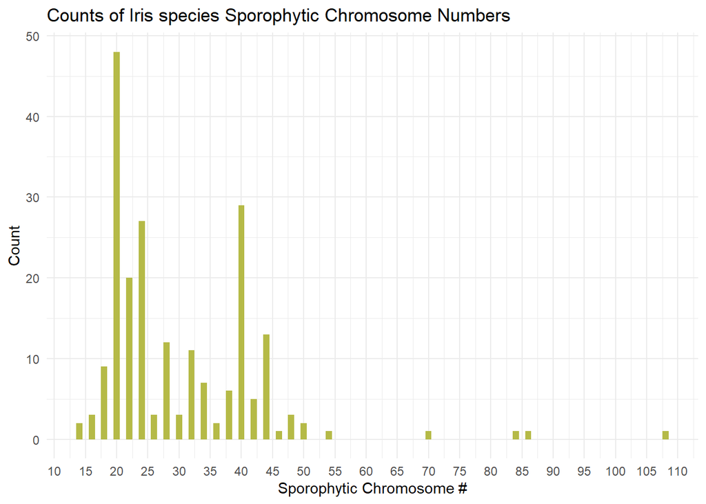

```r
# basic histogram - i wanted more scale bars which is what scale_x_continuous and scale_y_continuous are for
# Iris should be italicized but it seems like that requires packages i have no interest in figuring out
ggplot(data = clean_iris_chrom_modes, aes(x = sporophytic, group = species)) +
  geom_histogram(binwidth = 1, fill = "#B5BA47") +
  scale_x_continuous(breaks = seq(0, 110, by = 5)) +
  scale_y_continuous(breaks = seq(0, 50, by = 10)) +
  theme_minimal() +
  labs(x = "Sporophytic Chromosome #", y = "Count", title = "Counts of Iris species Sporophytic Chromosome Numbers")
```

## Question 3

The modes of the sporophytic stage chromosme count are 38 for *setosa*, 108 for *versicolor*, and 70 for *virginica*. *Iris versicolor*’s sporophytic chromosome count, 108, is the exact same as the sum of *setosa* and *virginica*’s (mode) chromosome counts, supporting the hybrid theory.

```r
# did view(clean_iris_chrom_modes) and manually found the rows that had the species of interest - could probably automate w regex to get the rows w each name but idc
clean_iris_chrom_modes %>%
  slice(166, 197, 199)
```

```
## # A tibble: 3 × 3
##   species    parsed_n sporophytic
##   <chr>         <dbl>       <dbl>
## 1 setosa           19          38
## 2 versicolor       54         108
## 3 virginica        35          70
```

# Part IV: Producing a scientific argument

## Question 1

Geographically, we can clearly see that *setosa* is distinct, looking at its localization. It’s likely that *setosa* and *virginica* diverged from each other due to geographic isolation, and this may be why it’s possible for them to interbreed, since later reproductive barriers weren’t necessary to be evolved to prevent hybridization (though obviously, evolution is not consciously done, and they could have evolved later reproductive barriers regardless due to stochastic change or drift).

Temporally, we see a similar pattern with *versicolor* being in between *setosa* and *virginica*, again supporting the idea that it results from interbreeding, but not proving it.

Using the chromosome data, assuming that the mode values are the correct values, we can observe that versicolor has 108 chromosomes, which is exactly the sum of 38 and 70, which are the chromosome numbers of *setosa* and *virginica*. Also, we see that many species have the same number of chromosomes, but versicolor is the *only* species with 108 chromosomes, suggesting that it is, in fact, a different species from *virginica*, which it more closely resembles.

While each separate approach doesn’t provide definitive proof that *versicolor* is a hybrid resulting from breeding of iris *setosa* and *virginica*, it is unlikely that all of these in combination are simply coincidence.

I find the chromosome counts and the morphological patterns to be the most compelling. The chromosome counts adding up exactly seems really unlikely to have evolved independently for seemingly no reason, and this is very easily explained by the hybridization theory. The fact that the three species can be distinguished with patterns based on just sepal and petal measurements seems like it proves that these are three distinct species as well, but we also don’t know if the lda based on that one dataset will be able to accurately predict species from a different dataset of the same irises, since the lda can only account for variation/values present within the iris dataset that the predictions were made with.

I do think that Anderson’s designations were correct, but *versicolor* and *virginica* are quite similar which did make me unsure about Anderson’s designations for them, especially when they overlap enough that the lda prediction misclassifies a few. Geographic information didn’t really help, because the two similar species are still close together in space while the distinct species (*setosa*) is separate which gives us no new information. The temporal data, while slightly different between species, was still too close and overlapping to truly tell us anything about temporal isolation.

If I didn’t have chromosomal data, I would probably say that *setosa* is definitely a distinct species, but it is difficult to determine if *versicolor* and *virginica* are different species from each other. However, given the chromosomal data, it seems very clear that *versicolor* and *virginica* are fundamentally different, and if they’re unable to interbreed with each other, given the biological species concept they are two separate species. Of course, we can’t really remark on that with the data that we have, but I think it is likely that *Iris setosa*, *versicolor*, and *virginica* represent three similar but distinct species.